# Pot Survey – Shakedown September 2022

August 29 - Sept 1, 2022 *F/V Integrity* West Ocean City, MD

Author

Mike O’Brien (UMCES)

[interactive chart not shown]

## Packing list

🔲 Large cooler

🔲 Sampling bags

🔲 Data sheets/clipboard

🔲 Two kill buckets

🔲 GPS

🔲 MS222

🔲 Measuring board

🔲 Weight bucket with scales

🔲 Fish totes

## Participants

### August 29

- Dave Secor: 301-481-5053
- Mike O’Brien: 267-970-1973

### August 30 - Sept 1

- Dave Secor
- Mike O’Brien
- Capt. Kerry Harrington
- *Integrity* mate, Reilly

## Schedule

### 29 August

Scientific crew (DHS, MOB)

- 0800 - 0900 Pack CBL truck (2017 Silverado) at Solomons, MD. Drive to West Ocean City, MD
- 0900 - 1230 Drive to MD Coastal Bays Program office
  - 8219 Stephen Decatur Hwy, Berlin, MD 21811
- 1230 - 1250 Load pots and two rope drums onto trailer
- 1250 - 1300 Drive to Sea Born, Inc.
  - 12906 Sunset Ave, Ocean City, MD 21842 Full crew (DHS, MOB, KH, mate)
- 1300 - 1330 Unload pots. KH/mate begin loading pots onto vessel.
- 1330 - 1530 DHS/MOB drive to MD Coastal Bays Program. Repeat pot loading/return/unloading.
- 1530 - 1600 Drop trailer off at MDCBP. Return to W Ocean City.
- 1600 - 1800 Finish rigging ground line
- 1800 Check into Microtel
  - 12536 Ocean Gateway, Ocean City, MD 21842

### 30 August

Full crew (DHS, MOB, KH, mate)

- 02:30 Meet at *F/V Integrity*
- 03:00 Depart ocmd for **K07**
- **38 21.2012, -74 42.1501**
- 05:25 Arrive **K07**. Deploy pots.
- 05:35 Finish deploying pots. Depart for **K10**
- **38 18.1654, -74 42.6398**
- 06:00 Arrive **K10**. Deploy pots.
- 06:10 Finish deploying pots. Depart for **J11**
- **38 17.1557, -74 43.7804**
- 06:25 Arrive **J11**. Deploy pots.
- 06:35 Finish deploying pots. Depart for **O12**
- **38 16.1313, -74 39.0571**
- 07:05 Arrive **O12**. Deploy pots.
- 07:15 Finish deploying pots. Depart for **2209_1**
- **38 13.4668, -74 37.9816**
- 07:40 Arrive **2209_1**. Deploy pots.
- 07:50 Finish deploying pots. Depart for **2209_2**
- **38 12.5833, -74 46.641**
- 08:45 Arrive **2209_2**. Deploy pots.
- 08:55 Finish deploying pots. Depart for **ocmd**
- 11:05 Arrive **ocmd**

Pick up dry ice from Harris Teeter

- 31221 Americana Pkwy, Selbyville, DE 19975

### 31 August

Full crew (DHS, MOB, KH, mate)

- 02:30 Meet at *F/V Integrity*
- 03:00 Depart ocmd for **K07**
- 05:25 Arrive **K07**. Deploy pots.
- 05:40 Finish deploying pots. Depart for **K10**
- 06:05 Arrive **K10**. Deploy pots.
- 06:20 Finish deploying pots. Depart for **J11**
- 06:35 Arrive **J11**. Deploy pots.
- 06:50 Finish deploying pots. Depart for **O12**
- 07:20 Arrive **O12**. Deploy pots.
- 07:35 Finish deploying pots. Depart for **2209_1**
- 08:00 Arrive **2209_1**. Deploy pots.
- 08:15 Finish deploying pots. Depart for **2209_2**
- 09:10 Arrive **2209_2**. Deploy pots.
- 09:25 Finish deploying pots. Depart for **ocmd**
- 11:35 Arrive **ocmd**
- 11:55 Pick up trailer from MD Coastal Bays Program
- 12:10 Remove pots from F/V Integrity, load onto trailer. Unload at MD Coastal Bays program. Repeat as needed.

13:35 Scientific crew drive back to Solomons, MD

## Distances

Distance, nautical miles

|  | ocmd | 2209_1 | 2209_2 | O12 | J11 | K07 | K10 |
| --- | --- | --- | --- | --- | --- | --- | --- |
| ocmd | 0.00 | 23.01 | 16.91 | 21.60 | 17.78 | 18.94 | 18.56 |
| 2209_1 | 23.01 | 0.00 | 6.87 | 2.80 | 5.86 | 8.40 | 5.96 |
| 2209_2 | 16.91 | 6.87 | 0.00 | 6.94 | 5.10 | 9.32 | 6.41 |
| O12 | 21.60 | 2.80 | 6.94 | 0.00 | 3.85 | 5.62 | 3.47 |
| J11 | 17.78 | 5.86 | 5.10 | 3.85 | 0.00 | 4.25 | 1.35 |
| K07 | 18.94 | 8.40 | 9.32 | 5.62 | 4.25 | 0.00 | 3.06 |
| K10 | 18.56 | 5.96 | 6.41 | 3.47 | 1.35 | 3.06 | 0.00 |

Distance, time

|  | ocmd | 2209_1 | 2209_2 | O12 | J11 | K07 | K10 |
| --- | --- | --- | --- | --- | --- | --- | --- |
| ocmd | - | 02 h 55 m | 02 h 10 m | 02 h 45 m | 02 h 15 m | 02 h 25 m | 02 h 20 m |
| 2209_1 | 02 h 55 m | - | 00 h 55 m | 00 h 25 m | 00 h 45 m | 01 h 05 m | 00 h 45 m |
| 2209_2 | 02 h 10 m | 00 h 55 m | - | 00 h 55 m | 00 h 40 m | 01 h 10 m | 00 h 50 m |
| O12 | 02 h 45 m | 00 h 25 m | 00 h 55 m | - | 00 h 30 m | 00 h 45 m | 00 h 30 m |
| J11 | 02 h 15 m | 00 h 45 m | 00 h 40 m | 00 h 30 m | - | 00 h 35 m | 00 h 15 m |
| K07 | 02 h 25 m | 01 h 05 m | 01 h 10 m | 00 h 45 m | 00 h 35 m | - | 00 h 25 m |
| K10 | 02 h 20 m | 00 h 45 m | 00 h 50 m | 00 h 30 m | 00 h 15 m | 00 h 25 m | - |

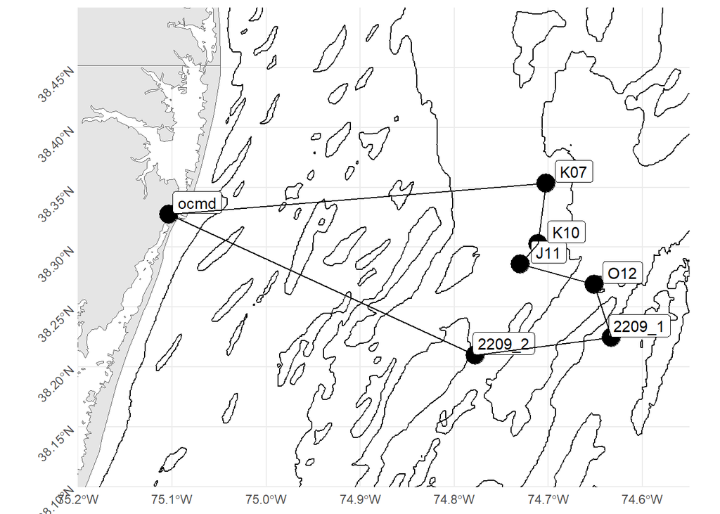